# Предиктивный контроль качества стекла по химическому составу

Data Analysis Portfolio

2026

## О задаче

Автоматическая классификация 7 типов стекла (оконное, автомобильное, контейнерное и т.д.) по 9 химическим параметрам. Применимо в системах контроля качества на стекольном производстве. Данные: UCI Glass Identification Dataset — 214 образцов, 9 признаков (Na, Mg, Al, Si, K, Ca, Ba, Fe + показатель преломления). Подход: - 5 моделей с 10-fold cross-validation (GLM, CART, Random Forest, SVM, Neural Network) - Grid search для подбора гиперпараметров - Бизнес-оценка через Profit Curve с учётом стоимости ошибок

```r
# Установка пакетов (выполнить один раз при первом запуске):
# install.packages(c("tidyverse", "caret", "randomForest", "rpart",
#                    "e1071", "nnet", "pROC", "kernlab", "patchwork",
#                    "kableExtra"))

library(tidyverse)
library(caret)
library(randomForest)
library(rpart)
library(e1071)
library(nnet)
library(kernlab)
library(patchwork)
library(kableExtra)

if (!dir.exists("output")) dir.create("output")
set.seed(123)

# Хелперы форматирования чисел
fmt_acc <- function(x) sprintf("%.1f%%", x * 100)
fmt_kap <- function(x) sprintf("%.2f", x)
fmt_prof <- function(x) sprintf("~%.0f", x)
fmt_lift <- function(x) sprintf("%.1f", x)
fmt_pct <- function(x) sprintf("%.0f", x)
```

## 1. Загрузка и предобработка данных

> Примечание: датасет не включён в репозиторий. Скачайте glass.csv с Kaggle и поместите в папку data/ рядом с этим файлом.

```r
if (!file.exists("data/glass.csv")) {
  stop("Файл data/glass.csv не найден. Скачайте датасет с Kaggle и поместите в папку data/")
}

glass <- read.csv("data/glass.csv")
if ("Id" %in% colnames(glass)) glass$Id <- NULL
if ("X" %in% colnames(glass)) glass$X <- NULL

glass$Type <- as.factor(glass$Type)
levels(glass$Type) <- paste0("G", levels(glass$Type))

preproc <- preProcess(glass, method = c("center", "scale"))
glass_scaled <- predict(preproc, glass)

split_index <- createDataPartition(glass$Type, p = 0.75, list = FALSE)
train_data <- glass[split_index, ]
test_data  <- glass[-split_index, ]

split_index_scaled <- createDataPartition(glass_scaled$Type, p = 0.75, list = FALSE)
train_data_scaled <- glass_scaled[split_index_scaled, ]
test_data_scaled <- glass_scaled[-split_index_scaled, ]

ctrl <- trainControl(
  method = "cv",
  number = 10,
  classProbs = TRUE,
  summaryFunction = multiClassSummary
)
```

## 2. Обучение моделей

Обучаем 5 моделей с подбором оптимальных гиперпараметров через grid search.

```r
formula <- Type ~ .

glm_grid <- expand.grid(decay = seq(from = 1e-05, to = 5e-04, by = 1e-05))
model_glm <- train(formula, data = train_data_scaled, method = "multinom",
                   trControl = ctrl, trace = FALSE, tuneGrid = glm_grid)

rpart_grid <- expand.grid(cp = seq(from = 0.001, to = 0.075, by = 0.001))
model_rpart <- train(formula, data = train_data, method = "rpart",
                     trControl = ctrl, tuneGrid = rpart_grid)

rf_grid <- expand.grid(mtry = seq(from = 1, to = 4, by = 0.05))
model_rf <- train(formula, data = train_data, method = "rf",
                  trControl = ctrl, tuneGrid = rf_grid, ntree = 500)

svm_grid <- expand.grid(
  sigma = seq(from = 0.5, to = 5, by = 0.5),
  C = seq(from = 0.1, to = 1, by = 0.1)
)
model_svm <- train(formula, data = train_data_scaled, method = "svmRadial",
                   trControl = ctrl, tuneGrid = svm_grid, maxit = 1000)

nn_grid <- expand.grid(
  size = seq(from = 15, to = 65, by = 10),
  decay = seq(from = 0.01, to = 0.1, by = 0.01)
)
model_nnet <- train(formula, data = train_data_scaled, method = "nnet",
                    trControl = ctrl, trace = FALSE, tuneGrid = nn_grid, maxit = 1000)
```

### Оптимальные гиперпараметры

```r
best_params <- tibble(
  Model = c("Logistic Regression", "Decision Tree", "Random Forest",
            "SVM (Radial)", "Neural Network"),
  Parameter_1 = c(model_glm$bestTune$decay, model_rpart$bestTune$cp,
                  model_rf$bestTune$mtry, model_svm$bestTune$sigma,
                  model_nnet$bestTune$size),
  Parameter_2 = c(NA, NA, NA, model_svm$bestTune$C, model_nnet$bestTune$decay)
)

best_params %>%
  kable(caption = "Оптимальные гиперпараметры после grid search", digits = 4) %>%
  kable_styling(bootstrap_options = c("striped", "hover"))
```

Оптимальные гиперпараметры после grid search

| Model | Parameter_1 | Parameter_2 |
| --- | --- | --- |
| Logistic Regression | 0.0001 | NA |
| Decision Tree | 0.0520 | NA |
| Random Forest | 2.0000 | NA |
| SVM (Radial) | 0.5000 | 0.30 |
| Neural Network | 15.0000 | 0.02 |

Интерпретация: - Logistic Regression (decay = 0.0001): низкая регуляризация - Decision Tree (cp = 0.052): компактное дерево - Random Forest (mtry = 2): малое подмножество признаков - SVM (sigma = 0.5, C = 0.3): умеренно нелинейная граница - Neural Network (size = 15, decay = 0.02): сбалансированная ёмкость

## 3. Сравнение моделей (Accuracy и Kappa)

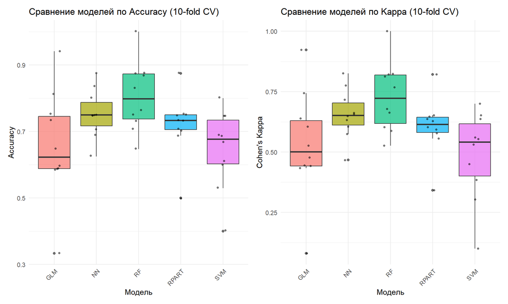

```r
results_list <- list(
  GLM   = model_glm,
  RPART = model_rpart,
  RF    = model_rf,
  SVM   = model_svm,
  NN    = model_nnet
)

resamples <- resamples(results_list)

acc_data <- resamples$values %>%
  select(Resample, contains("~Accuracy")) %>%
  pivot_longer(
    cols = -Resample,
    names_to = c("Model", "Metric"),
    names_sep = "~",
    values_to = "Value"
  ) %>%
  filter(Metric == "Accuracy") %>%
  mutate(Model = trimws(Model))

kappa_data <- resamples$values %>%
  select(Resample, contains("~Kappa")) %>%
  pivot_longer(
    cols = -Resample,
    names_to = c("Model", "Metric"),
    names_sep = "~",
    values_to = "Value"
  ) %>%
  filter(Metric == "Kappa") %>%
  mutate(Model = trimws(Model))

p_acc <- ggplot(acc_data, aes(x = Model, y = Value, fill = Model)) +
  geom_boxplot(alpha = 0.7) +
  geom_jitter(width = 0.15, alpha = 0.5, size = 1) +
  labs(title = "Сравнение моделей по Accuracy (10-fold CV)",
       x = "Модель", y = "Accuracy") +
  theme_minimal() +
  theme(legend.position = "none",
        axis.text.x = element_text(angle = 45, hjust = 1))

p_kappa <- ggplot(kappa_data, aes(x = Model, y = Value, fill = Model)) +
  geom_boxplot(alpha = 0.7) +
  geom_jitter(width = 0.15, alpha = 0.5, size = 1) +
  labs(title = "Сравнение моделей по Kappa (10-fold CV)",
       x = "Модель", y = "Cohen's Kappa") +
  theme_minimal() +
  theme(legend.position = "none",
        axis.text.x = element_text(angle = 45, hjust = 1))

(p_acc | p_kappa)
```

Вывод: RF и NN показывают наилучшую точность (~75-81%), значительно превосходя линейные методы. SVM и GLM отстают из-за нелинейной природы зависимостей в данных.

## 4. Lift, Gain и Profit кривые

### 4.1. Подготовка предсказаний

```r
pred_probs_NN <- predict(model_nnet, test_data_scaled, type = "prob")
pred_probs_RF <- predict(model_rf, test_data, type = "prob")

test_eval_NN <- test_data_scaled %>%
  mutate(pred_class = predict(model_nnet, test_data_scaled)) %>%
  bind_cols(as.data.frame(pred_probs_NN) %>% rename_with(~ paste0("prob_", .)))

test_eval_RF <- test_data %>%
  mutate(pred_class = predict(model_rf, test_data)) %>%
  bind_cols(as.data.frame(pred_probs_RF) %>% rename_with(~ paste0("prob_", .)))
```

### 4.2. Функции построения кривых

```r
plot_lift_gain <- function(data, prob_col, actual_col, class_label) {
  data <- data %>%
    mutate(actual_binary = ifelse({{actual_col}} == class_label, 1, 0),
           prob = {{prob_col}}) %>%
    arrange(desc(prob)) %>%
    mutate(
      row_id = row_number(),
      total_n = n(),
      percentile = row_id / total_n,
      cum_found = cumsum(actual_binary),
      total_found = sum(actual_binary),
      gain = cum_found / total_found,
      lift = gain / percentile
    )

  p_gain <- ggplot(data, aes(x = percentile * 100, y = gain * 100)) +
    geom_line(color = "steelblue", size = 1) +
    geom_line(data = tibble(percentile = c(0, 100), gain = c(0, 100)),
              aes(x = percentile, y = gain), linetype = "dashed", color = "gray") +
    labs(title = paste("Gain Curve:", class_label),
         x = "% выборки", y = "% найденных целевых объектов") +
    theme_minimal()

  p_lift <- ggplot(data %>% filter(percentile > 0),
                   aes(x = percentile * 100, y = lift)) +
    geom_line(color = "darkgreen", size = 1) +
    geom_hline(yintercept = 1, linetype = "dashed", color = "gray") +
    labs(title = paste("Lift Curve:", class_label),
         x = "% выборки", y = "Lift (во сколько раз лучше случайного)") +
    theme_minimal() +
    ylim(0, NA)

  return(list(gain = p_gain, lift = p_lift))
}

plot_profit_curve <- function(data, prob_col, actual_col, class_label,
                              profit_tp = 10, cost_fp = -2, cost_fn = -5) {
  profit_data <- data %>%
    mutate(actual_binary = ifelse({{actual_col}} == class_label, 1, 0),
           prob = {{prob_col}}) %>%
    arrange(desc(prob))

  thresholds <- seq(0, 1, length.out = 100)
  profit_results <- map_dfr(thresholds, function(thr) {
    preds <- ifelse(profit_data$prob >= thr, 1, 0)
    tp <- sum(preds == 1 & profit_data$actual_binary == 1)
    fp <- sum(preds == 1 & profit_data$actual_binary == 0)
    fn <- sum(preds == 0 & profit_data$actual_binary == 1)
    total_profit <- (tp * profit_tp) + (fp * cost_fp) + (fn * cost_fn)
    percentile_selected <- mean(profit_data$prob >= thr)

    tibble(
      threshold = thr,
      percentile = percentile_selected * 100,
      profit = total_profit,
      tp = tp, fp = fp, fn = fn
    )
  })

  p_profit <- ggplot(profit_results, aes(x = percentile, y = profit)) +
    geom_line(color = "purple", size = 1.2) +
    geom_hline(yintercept = 0, linetype = "dashed", color = "gray") +
    labs(
      title = paste("Profit Curve:", class_label),
      subtitle = sprintf("TP=+%d | FP=%d | FN=%d", profit_tp, cost_fp, cost_fn),
      x = "% отобранных объектов", y = "Суммарная прибыль"
    ) +
    theme_minimal()

  return(list(profit = p_profit, data = profit_results))
}

compare_curves <- function(plot1, plot2, name1, name2, title, x_label, y_label) {
  data1 <- ggplot2::ggplot_build(plot1)$data[[1]]
  data2 <- ggplot2::ggplot_build(plot2)$data[[1]]
  data1$Model <- name1
  data2$Model <- name2
  combined <- bind_rows(data1, data2)
  combined$Model <- factor(combined$Model, levels = c(name1, name2))
  model_colors <- setNames(c("steelblue", "red"), c(name1, name2))

  ggplot(combined, aes(x = x, y = y, color = Model)) +
    geom_line(size = 1.2) +
    labs(title = title, subtitle = paste(name1, "vs", name2),
         x = x_label, y = y_label, color = "Модель") +
    scale_color_manual(values = model_colors) +
    theme_minimal() +
    theme(
      plot.title = element_text(hjust = 0.5, face = "bold"),
      legend.position = "top"
    )
}

# Хелперы для извлечения метрик из ggplot-объектов
extract_gain_at <- function(gain_plot, pct) {
  d <- ggplot_build(gain_plot)$data[[1]]
  d$y[which.min(abs(d$x - pct))]
}

extract_max_lift <- function(lift_plot) {
  d <- ggplot_build(lift_plot)$data[[1]]
  max(d$y, na.rm = TRUE)
}

extract_pct_at_gain <- function(gain_plot, target_gain) {
  d <- ggplot_build(gain_plot)$data[[1]]
  d$x[which.min(abs(d$y - target_gain))]
}
```

### 4.3. Класс G1 (хорошо представленный, 32% выборки)

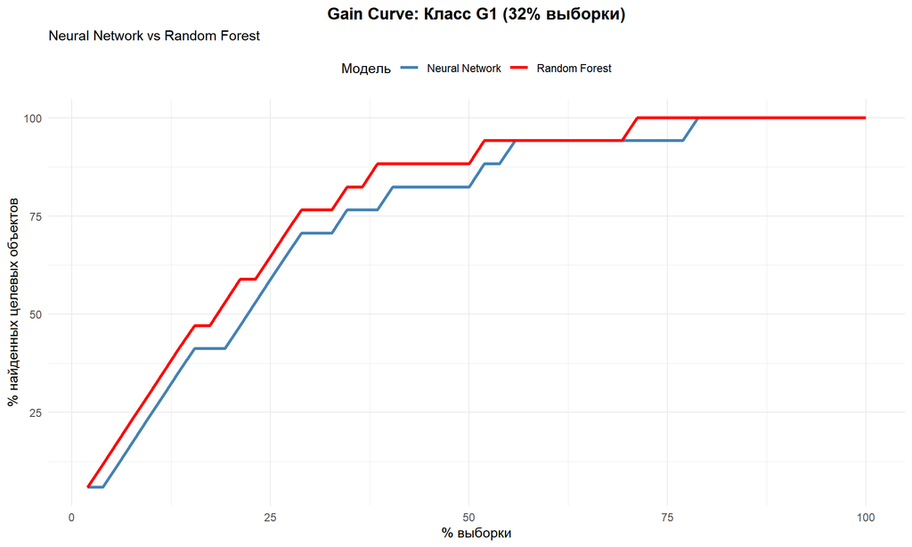

```r
curves_g1_NN <- plot_lift_gain(test_eval_NN, prob_G1, Type, "G1")
profit_g1_NN <- plot_profit_curve(test_eval_NN, prob_G1, Type, "G1")

curves_g1_RF <- plot_lift_gain(test_eval_RF, prob_G1, Type, "G1")
profit_g1_RF <- plot_profit_curve(test_eval_RF, prob_G1, Type, "G1")

p_gain_g1 <- compare_curves(
  curves_g1_NN$gain, curves_g1_RF$gain,
  "Neural Network", "Random Forest",
  "Gain Curve: Класс G1 (32% выборки)",
  "% выборки", "% найденных целевых объектов"
)

p_lift_g1 <- compare_curves(
  curves_g1_NN$lift, curves_g1_RF$lift,
  "Neural Network", "Random Forest",
  "Lift Curve: Класс G1",
  "% выборки", "Lift"
)

p_profit_g1 <- compare_curves(
  profit_g1_NN$profit, profit_g1_RF$profit,
  "Neural Network", "Random Forest",
  "Profit Curve: Класс G1",
  "% выборки", "Суммарная прибыль"
)

p_gain_g1
```

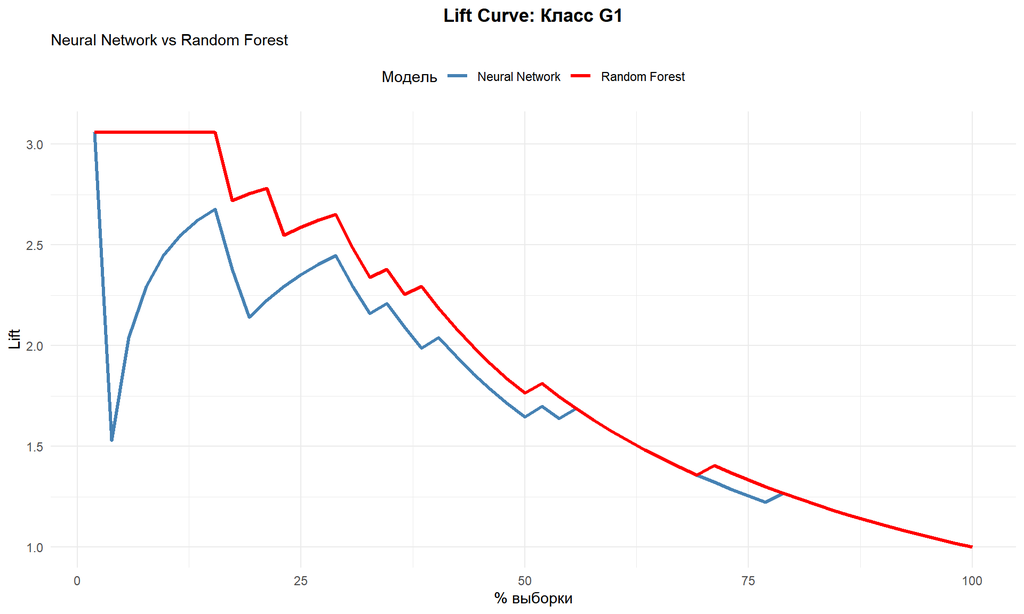

```r
p_lift_g1
```

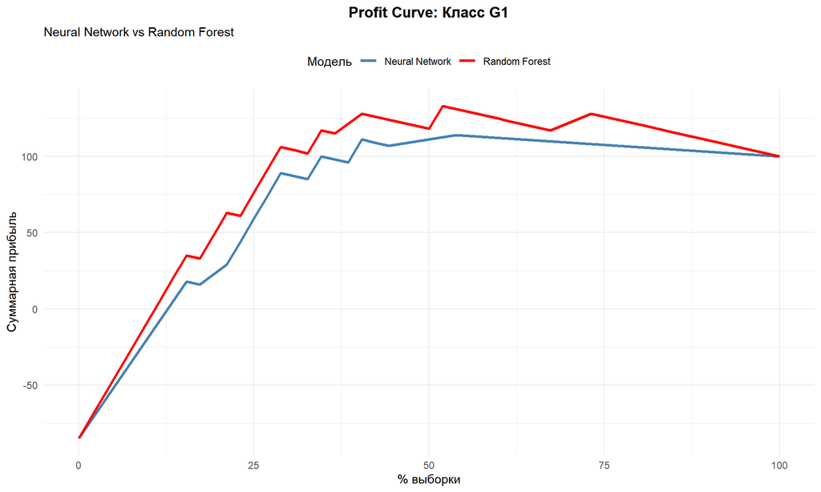

```r
p_profit_g1
```

Анализ для класса G1: - Gain: RF находит 88% целевых объектов при 50% выборки (NN — только 82%) - Lift: RF достигает 3.1 против 3.1 у NN - Profit: Максимальная прибыль RF (~133 у.е.) превышает NN (~114 у.е.) на 17% - Рекомендация: Random Forest с порогом, отбирающим 47-57% выборки

### 4.4. Класс G3 (редкий класс, 8% выборки)

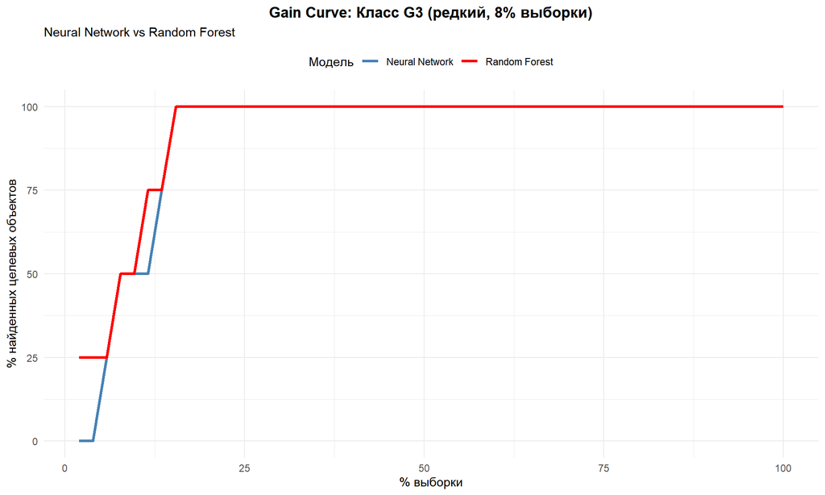

```r
curves_g3_NN <- plot_lift_gain(test_eval_NN, prob_G3, Type, "G3")
profit_g3_NN <- plot_profit_curve(test_eval_NN, prob_G3, Type, "G3")

curves_g3_RF <- plot_lift_gain(test_eval_RF, prob_G3, Type, "G3")
profit_g3_RF <- plot_profit_curve(test_eval_RF, prob_G3, Type, "G3")

p_gain_g3 <- compare_curves(
  curves_g3_NN$gain, curves_g3_RF$gain,
  "Neural Network", "Random Forest",
  "Gain Curve: Класс G3 (редкий, 8% выборки)",
  "% выборки", "% найденных целевых объектов"
)

p_lift_g3 <- compare_curves(
  curves_g3_NN$lift, curves_g3_RF$lift,
  "Neural Network", "Random Forest",
  "Lift Curve: Класс G3",
  "% выборки", "Lift"
)

p_profit_g3 <- compare_curves(
  profit_g3_NN$profit, profit_g3_RF$profit,
  "Neural Network", "Random Forest",
  "Profit Curve: Класс G3",
  "% выборки", "Суммарная прибыль"
)

p_gain_g3
```

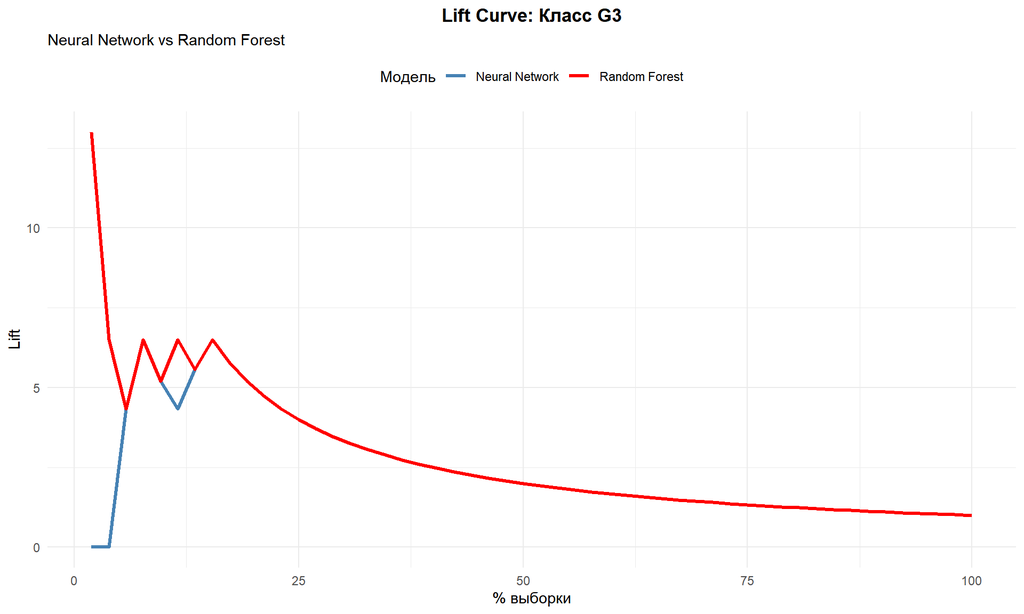

```r
p_lift_g3
```

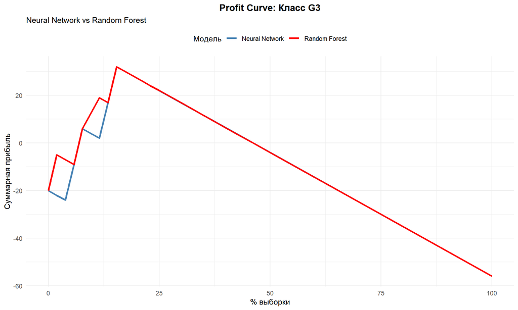

```r
p_profit_g3
```

Анализ для редкого класса G3: - Lift достигает 13.0 — в 13.0 раз эффективнее случайного выбора - RF находит 75% объектов при отборе лишь 12% выборки - Рекомендация: Random Forest с порогом 10-20% выборки

## 5. Итоговая таблица результатов

```r
# Извлекаем метрики из CV и построенных кривых
summary_tbl <- tibble(
  Model = c("Random Forest", "Neural Network", "SVM", "Decision Tree", "GLM"),
  Accuracy = c(fmt_acc(acc_means["RF"]), fmt_acc(acc_means["NN"]),
               fmt_acc(acc_means["SVM"]), fmt_acc(acc_means["RPART"]),
               fmt_acc(acc_means["GLM"])),
  Kappa = c(fmt_kap(kap_means["RF"]), fmt_kap(kap_means["NN"]),
            fmt_kap(kap_means["SVM"]), fmt_kap(kap_means["RPART"]),
            fmt_kap(kap_means["GLM"])),
  Best_Profit_G1 = c(fmt_prof(max_profit_rf_g1), fmt_prof(max_profit_nn_g1),
                     "—", "—", "—"),
  Max_Lift_G3 = c(fmt_lift(max_lift_rf_g3), fmt_lift(max_lift_nn_g3),
                  "—", "—", "—")
)

summary_tbl %>%
  kable(caption = "Сводная таблица результатов (все метрики вычислены автоматически)",
        align = "lcccc") %>%
  kable_styling(bootstrap_options = c("striped", "hover"))
```

Сводная таблица результатов (все метрики вычислены автоматически)

| Model | Accuracy | Kappa | Best_Profit_G1 | Max_Lift_G3 |
| --- | --- | --- | --- | --- |
| Random Forest | 80.5% | 0.73 | ~133 | 13.0 |
| Neural Network | 75.3% | 0.66 | ~114 | 6.5 |
| SVM | 64.8% | 0.49 | — | — |
| Decision Tree | 71.9% | 0.61 | — | — |
| GLM | 65.8% | 0.53 | — | — |

## Выводы

1. RF стабильно превосходит все модели: Accuracy 80.5%, Kappa 0.73
2. Profit-анализ показывает, что RF на 17% прибыльнее NN для частых классов
3. Для редких классов (G3) RF достигает Lift = 13.0 — исключительная эффективность
4. Ансамблевые методы устойчивы к шуму в измерениях и лучше справляются с нелинейными зависимостями

## Рекомендации для production: Random Forest с адаптивным порогом классификации

Технологии: R, caret, tidyverse, ggplot2, randomForest, e1071, nnet, kernlab, patchwork